# Red Wine Data Exploration by Mario Hinojosa

# Understanding the basic structure of the data

```
## 'data.frame':    1599 obs. of  13 variables:
##  $ X                   : int  1 2 3 4 5 6 7 8 9 10 ...
##  $ fixed.acidity       : num  7.4 7.8 7.8 11.2 7.4 7.4 7.9 7.3 7.8 7.5 ...
##  $ volatile.acidity    : num  0.7 0.88 0.76 0.28 0.7 0.66 0.6 0.65 0.58 0.5 ...
##  $ citric.acid         : num  0 0 0.04 0.56 0 0 0.06 0 0.02 0.36 ...
##  $ residual.sugar      : num  1.9 2.6 2.3 1.9 1.9 1.8 1.6 1.2 2 6.1 ...
##  $ chlorides           : num  0.076 0.098 0.092 0.075 0.076 0.075 0.069 0.065 0.073 0.071 ...
##  $ free.sulfur.dioxide : num  11 25 15 17 11 13 15 15 9 17 ...
##  $ total.sulfur.dioxide: num  34 67 54 60 34 40 59 21 18 102 ...
##  $ density             : num  0.998 0.997 0.997 0.998 0.998 ...
##  $ pH                  : num  3.51 3.2 3.26 3.16 3.51 3.51 3.3 3.39 3.36 3.35 ...
##  $ sulphates           : num  0.56 0.68 0.65 0.58 0.56 0.56 0.46 0.47 0.57 0.8 ...
##  $ alcohol             : num  9.4 9.8 9.8 9.8 9.4 9.4 9.4 10 9.5 10.5 ...
##  $ quality             : int  5 5 5 6 5 5 5 7 7 5 ...
```

Right, there seems to be the need for some simple data manipulation (i.e. remove X and factorize quality)

```
## 'data.frame':    1599 obs. of  12 variables:
##  $ fixed.acidity       : num  7.4 7.8 7.8 11.2 7.4 7.4 7.9 7.3 7.8 7.5 ...
##  $ volatile.acidity    : num  0.7 0.88 0.76 0.28 0.7 0.66 0.6 0.65 0.58 0.5 ...
##  $ citric.acid         : num  0 0 0.04 0.56 0 0 0.06 0 0.02 0.36 ...
##  $ residual.sugar      : num  1.9 2.6 2.3 1.9 1.9 1.8 1.6 1.2 2 6.1 ...
##  $ chlorides           : num  0.076 0.098 0.092 0.075 0.076 0.075 0.069 0.065 0.073 0.071 ...
##  $ free.sulfur.dioxide : num  11 25 15 17 11 13 15 15 9 17 ...
##  $ total.sulfur.dioxide: num  34 67 54 60 34 40 59 21 18 102 ...
##  $ density             : num  0.998 0.997 0.997 0.998 0.998 ...
##  $ pH                  : num  3.51 3.2 3.26 3.16 3.51 3.51 3.3 3.39 3.36 3.35 ...
##  $ sulphates           : num  0.56 0.68 0.65 0.58 0.56 0.56 0.46 0.47 0.57 0.8 ...
##  $ alcohol             : num  9.4 9.8 9.8 9.8 9.4 9.4 9.4 10 9.5 10.5 ...
##  $ quality             : Factor w/ 6 levels "3","4","5","6",..: 3 3 3 4 3 3 3 5 5 3 ...
```

# Univariate Plots Section

First step…let’s check the distribution of variables I believe might be interesting and transform them if they seem too skewed.

```
##  fixed.acidity   volatile.acidity  citric.acid    residual.sugar
##  Min.   : 4.60   Min.   :0.1200   Min.   :0.000   Min.   : 0.900
##  1st Qu.: 7.10   1st Qu.:0.3900   1st Qu.:0.090   1st Qu.: 1.900
##  Median : 7.90   Median :0.5200   Median :0.260   Median : 2.200
##  Mean   : 8.32   Mean   :0.5278   Mean   :0.271   Mean   : 2.539
##  3rd Qu.: 9.20   3rd Qu.:0.6400   3rd Qu.:0.420   3rd Qu.: 2.600
##  Max.   :15.90   Max.   :1.5800   Max.   :1.000   Max.   :15.500
##    chlorides       free.sulfur.dioxide total.sulfur.dioxide
##  Min.   :0.01200   Min.   : 1.00       Min.   :  6.00
##  1st Qu.:0.07000   1st Qu.: 7.00       1st Qu.: 22.00
##  Median :0.07900   Median :14.00       Median : 38.00
##  Mean   :0.08747   Mean   :15.87       Mean   : 46.47
##  3rd Qu.:0.09000   3rd Qu.:21.00       3rd Qu.: 62.00
##  Max.   :0.61100   Max.   :72.00       Max.   :289.00
##     density             pH          sulphates         alcohol      quality
##  Min.   :0.9901   Min.   :2.740   Min.   :0.3300   Min.   : 8.40   3: 10
##  1st Qu.:0.9956   1st Qu.:3.210   1st Qu.:0.5500   1st Qu.: 9.50   4: 53
##  Median :0.9968   Median :3.310   Median :0.6200   Median :10.20   5:681
##  Mean   :0.9967   Mean   :3.311   Mean   :0.6581   Mean   :10.42   6:638
##  3rd Qu.:0.9978   3rd Qu.:3.400   3rd Qu.:0.7300   3rd Qu.:11.10   7:199
##  Max.   :1.0037   Max.   :4.010   Max.   :2.0000   Max.   :14.90   8: 18
```

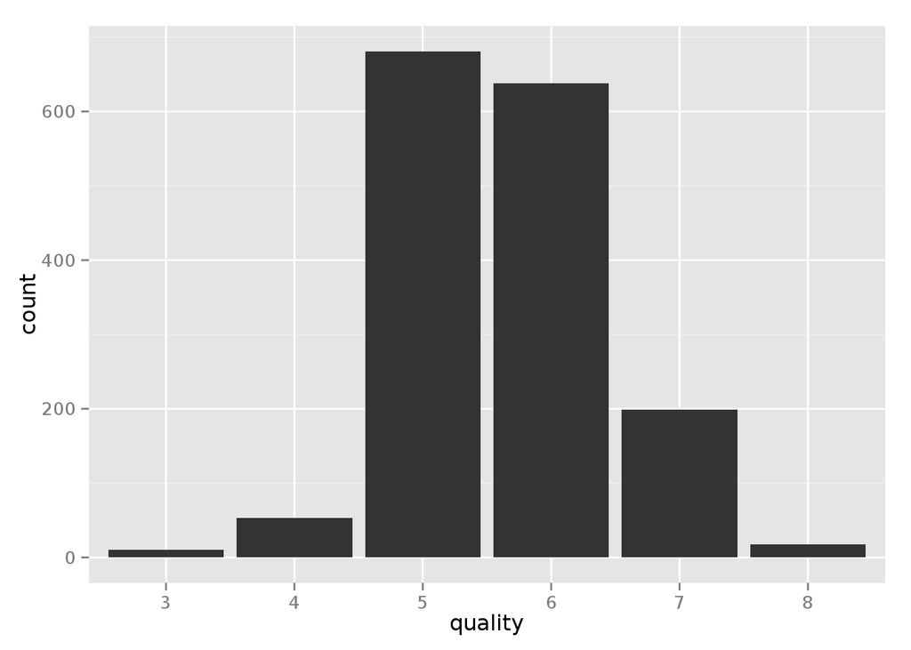

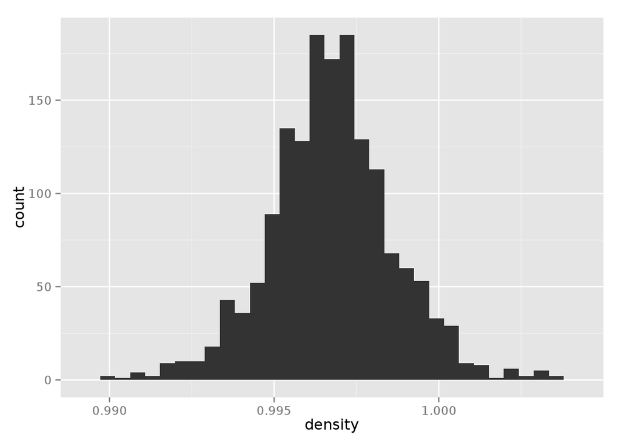

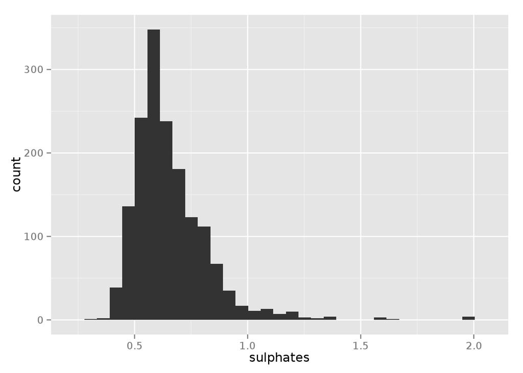

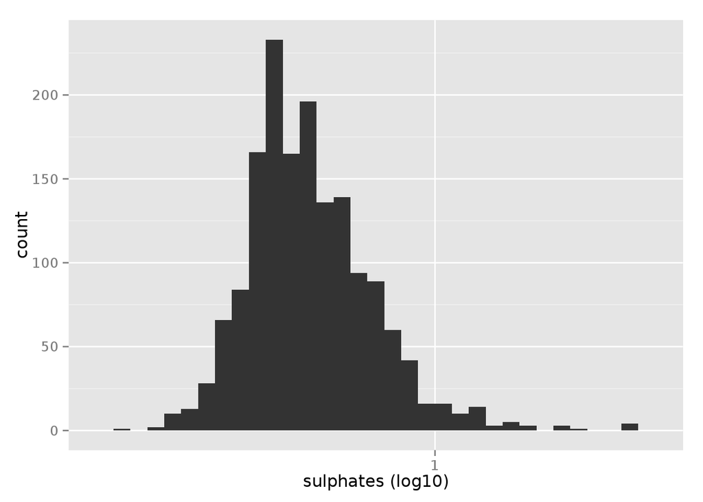

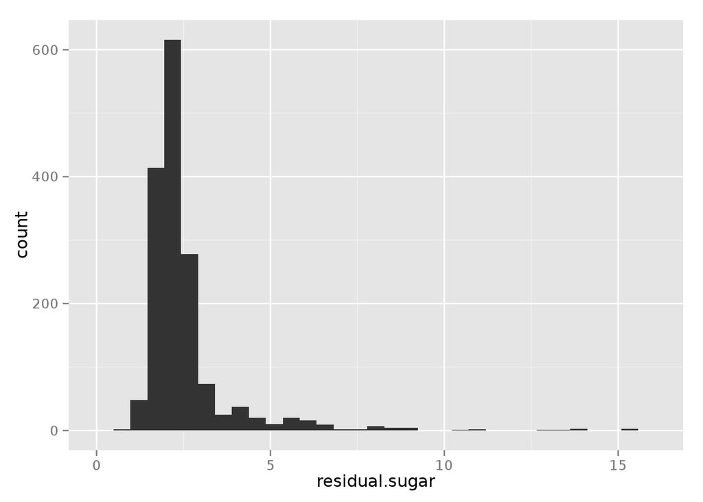

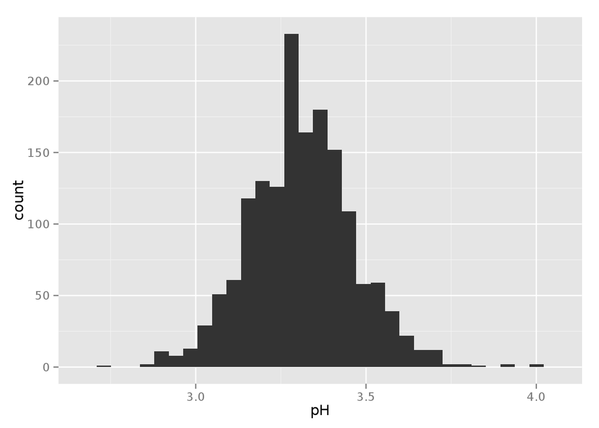

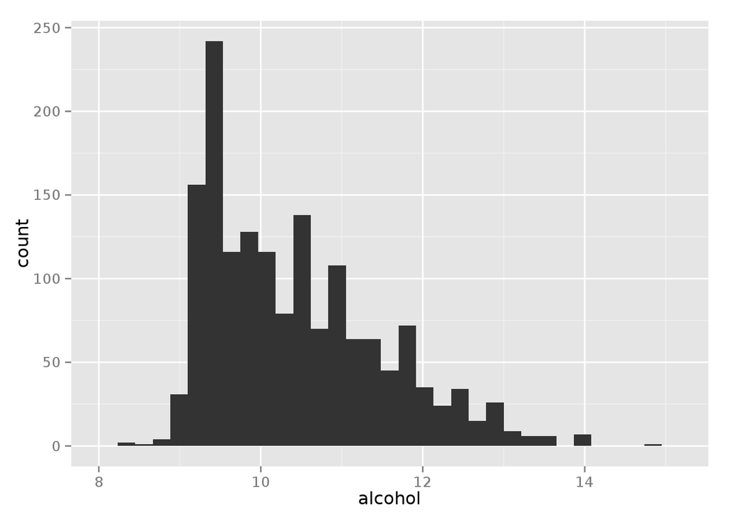

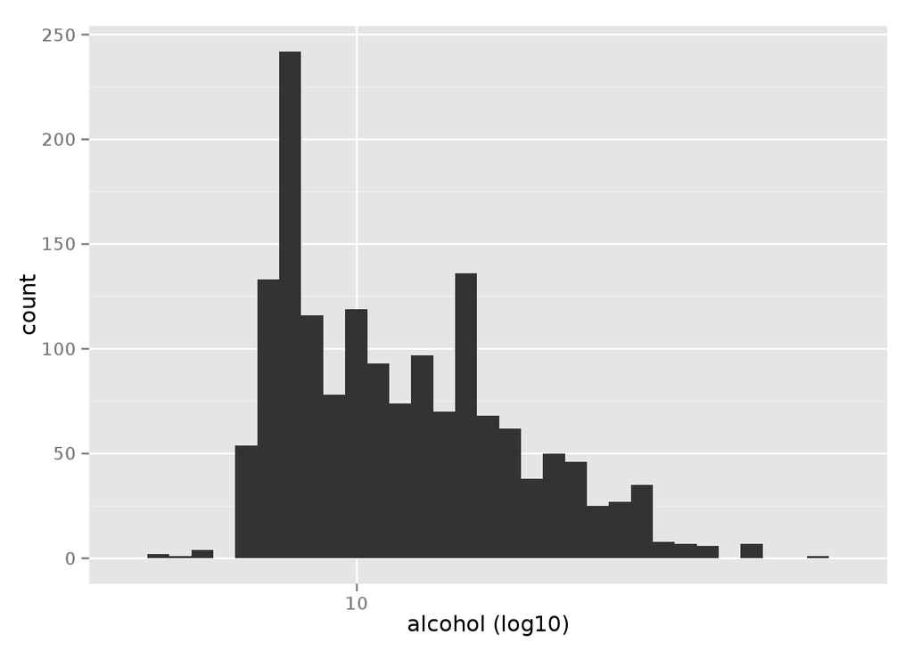

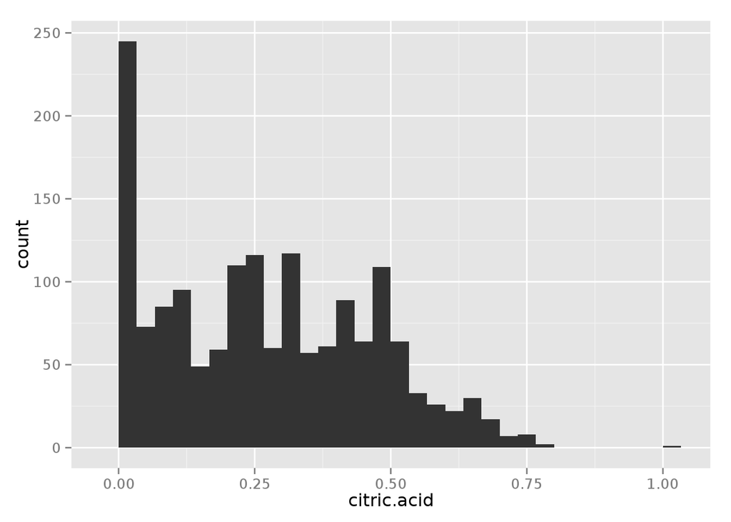

```
##  [1] 215  59  44  55  65  42  39  28  38  46  60  76  65  39  51  62  49
## [18]  33  33  57  45  38  41  41  88  30  27  20  18  17   3  19  21  13
## [35]   6   2   7   4   1   1   0   0   0   0   0   0   0   0   0   1
```

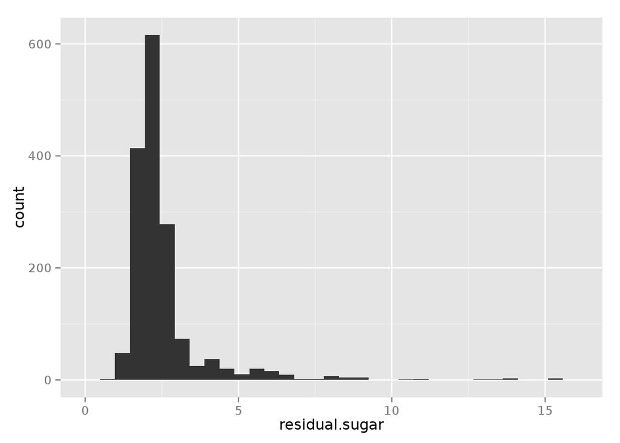

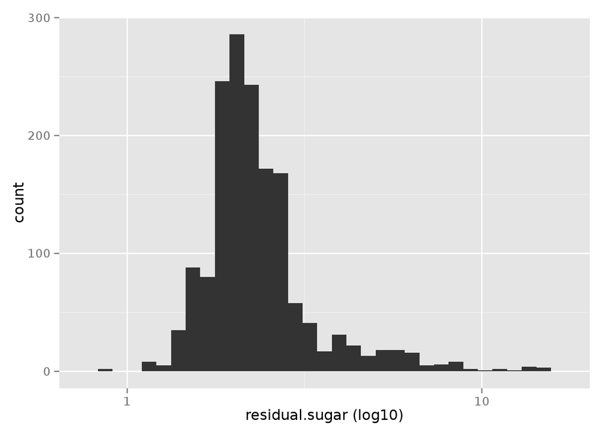

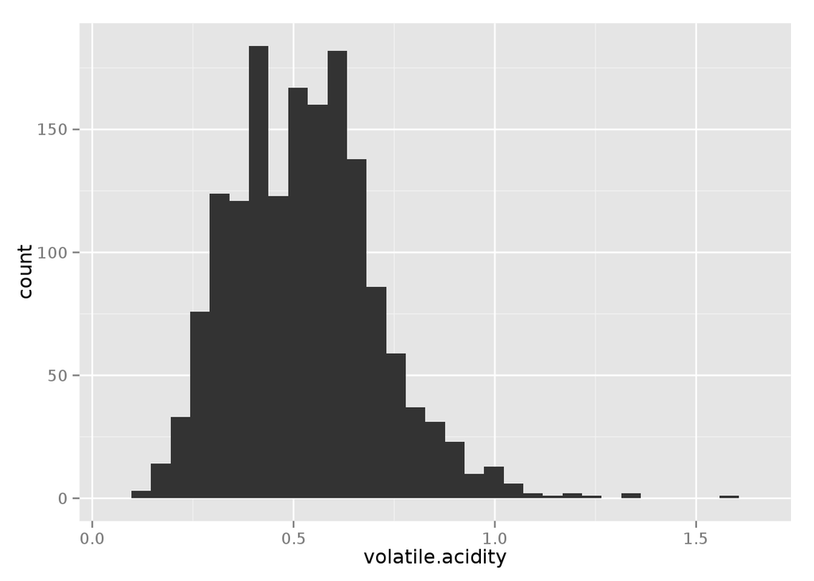

# Univariate Analysis

### What is the structure of your dataset?

- The red wine dataset (rddf) consists of 12 variables of which 11 are numerical data and measure different chemical properties of the red wine. There is a total of 1599 observations.
- `quality` is a factor variable which represents the quality of the wine graded on a scale between 0 (very bad) and 10 (very excellent). It seems that the majority of the observations received a grading between 5 and 6.
- none of the wines were graded very bad or very good (below 3 or above 8).
- several variables have outlier value in the upper range such as `volatile.acidity`, `residual.sugar`, `chlorides`, `free.sulfur.dioxide`, `total.sulfur.dioxide` and `sulphates`

### What is/are the main feature(s) of interest in your dataset?

After reading the dataset documentation, plotting some variables and from previous, albeit limited, personal knowledge about wine, I suspect that sulphates, volatile acidity and residual sugar are the main features that influence the quality of the wine.

### What other features in the dataset do you think will help support your investigation into your feature(s) of interest?

Probably pH, citric acid and fixed acidity will also be relevant to study in more detail in the following sections.

### Did you create any new variables from existing variables in the dataset?

At this point, given the basic exploration, I didn’t see the need to create any new variables.

# Bivariate Plots Section

Let’s plot all variables against each other to see have a clearer picture of their relationships

[figure not shown]

```
##                      fixed.acidity volatile.acidity citric.acid
## fixed.acidity           1.00000000     -0.256130895  0.67170343
## volatile.acidity       -0.25613089      1.000000000 -0.55249568
## citric.acid             0.67170343     -0.552495685  1.00000000
## residual.sugar          0.11477672      0.001917882  0.14357716
## chlorides               0.09370519      0.061297772  0.20382291
## free.sulfur.dioxide    -0.15379419     -0.010503827 -0.06097813
## total.sulfur.dioxide   -0.11318144      0.076470005  0.03553302
## density                 0.66804729      0.022026232  0.36494718
## pH                     -0.68297819      0.234937294 -0.54190414
## sulphates               0.18300566     -0.260986685  0.31277004
## alcohol                -0.06166827     -0.202288027  0.10990325
##                      residual.sugar    chlorides free.sulfur.dioxide
## fixed.acidity           0.114776724  0.093705186        -0.153794193
## volatile.acidity        0.001917882  0.061297772        -0.010503827
## citric.acid             0.143577162  0.203822914        -0.060978129
## residual.sugar          1.000000000  0.055609535         0.187048995
## chlorides               0.055609535  1.000000000         0.005562147
## free.sulfur.dioxide     0.187048995  0.005562147         1.000000000
## total.sulfur.dioxide    0.203027882  0.047400468         0.667666450
## density                 0.355283371  0.200632327        -0.021945831
## pH                     -0.085652422 -0.265026131         0.070377499
## sulphates               0.005527121  0.371260481         0.051657572
## alcohol                 0.042075437 -0.221140545        -0.069408354
##                      total.sulfur.dioxide     density          pH
## fixed.acidity                 -0.11318144  0.66804729 -0.68297819
## volatile.acidity               0.07647000  0.02202623  0.23493729
## citric.acid                    0.03553302  0.36494718 -0.54190414
## residual.sugar                 0.20302788  0.35528337 -0.08565242
## chlorides                      0.04740047  0.20063233 -0.26502613
## free.sulfur.dioxide            0.66766645 -0.02194583  0.07037750
## total.sulfur.dioxide           1.00000000  0.07126948 -0.06649456
## density                        0.07126948  1.00000000 -0.34169933
## pH                            -0.06649456 -0.34169933  1.00000000
## sulphates                      0.04294684  0.14850641 -0.19664760
## alcohol                       -0.20565394 -0.49617977  0.20563251
##                         sulphates     alcohol
## fixed.acidity         0.183005664 -0.06166827
## volatile.acidity     -0.260986685 -0.20228803
## citric.acid           0.312770044  0.10990325
## residual.sugar        0.005527121  0.04207544
## chlorides             0.371260481 -0.22114054
## free.sulfur.dioxide   0.051657572 -0.06940835
## total.sulfur.dioxide  0.042946836 -0.20565394
## density               0.148506412 -0.49617977
## pH                   -0.196647602  0.20563251
## sulphates             1.000000000  0.09359475
## alcohol               0.093594750  1.00000000
```

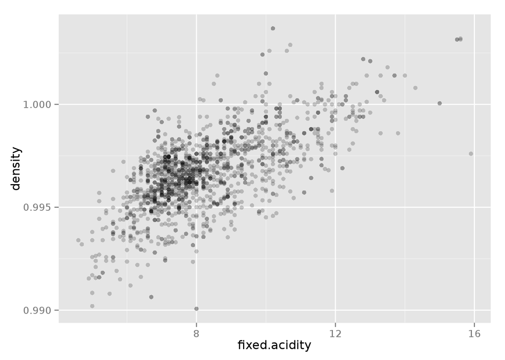

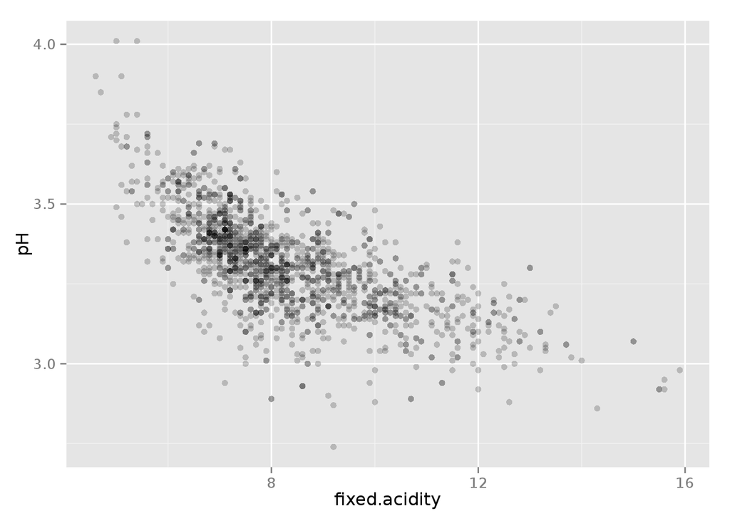

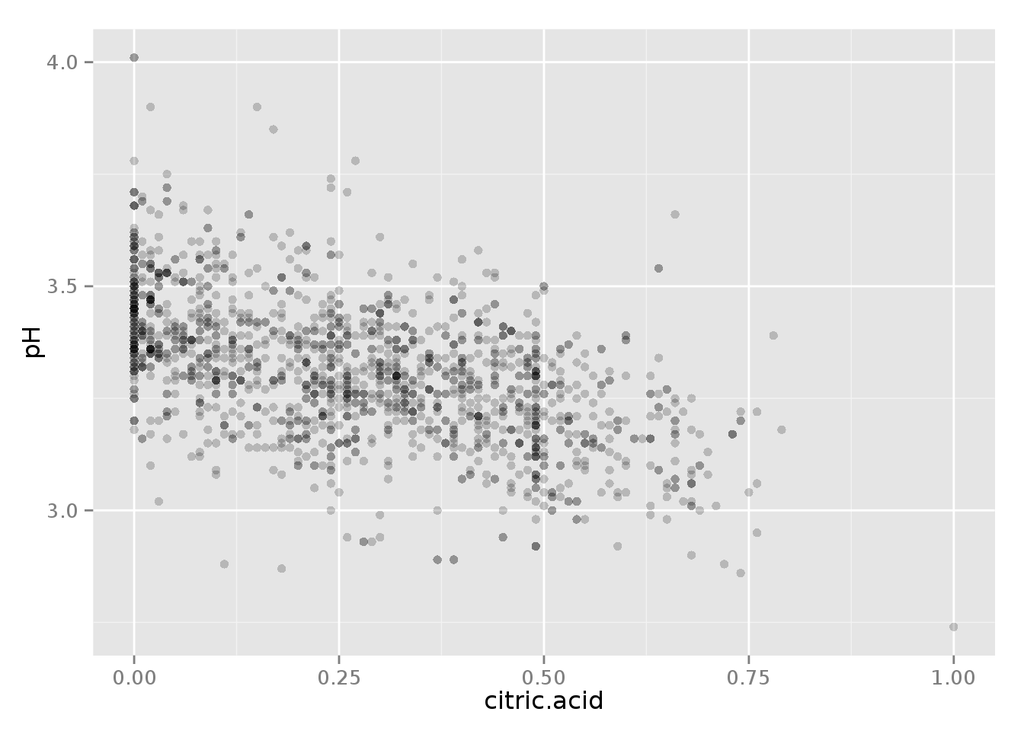

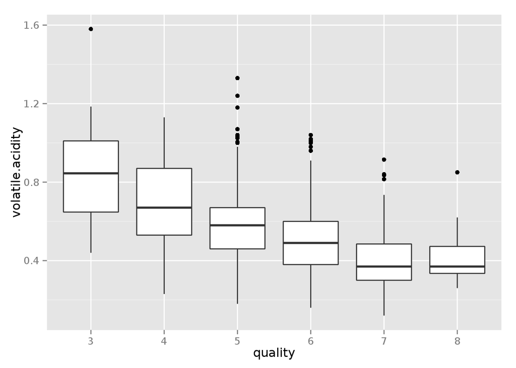

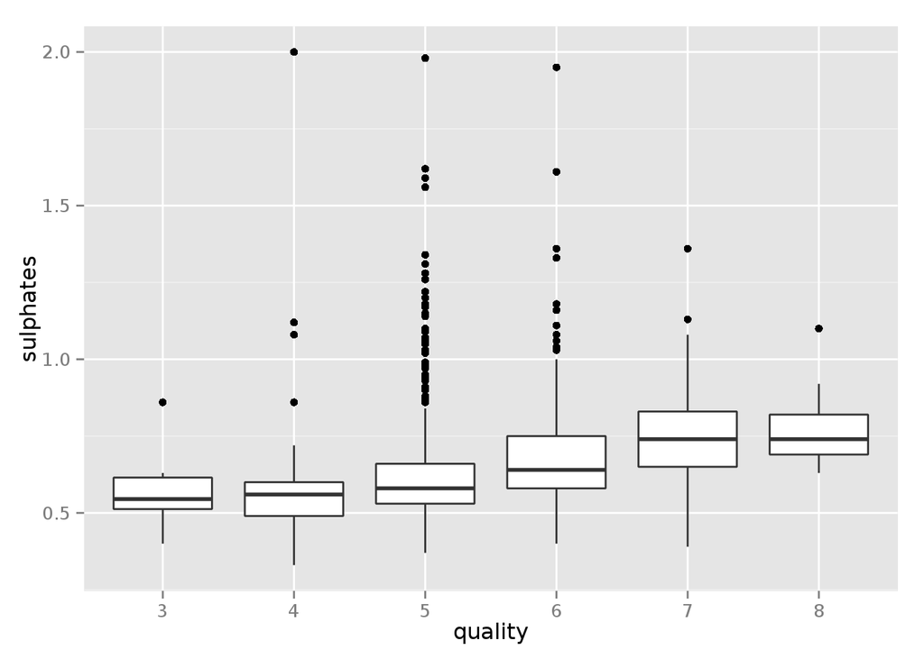

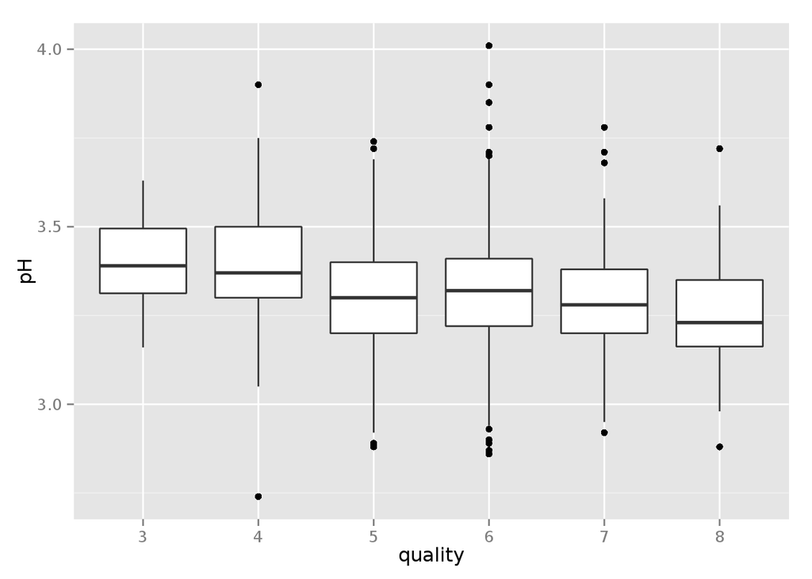

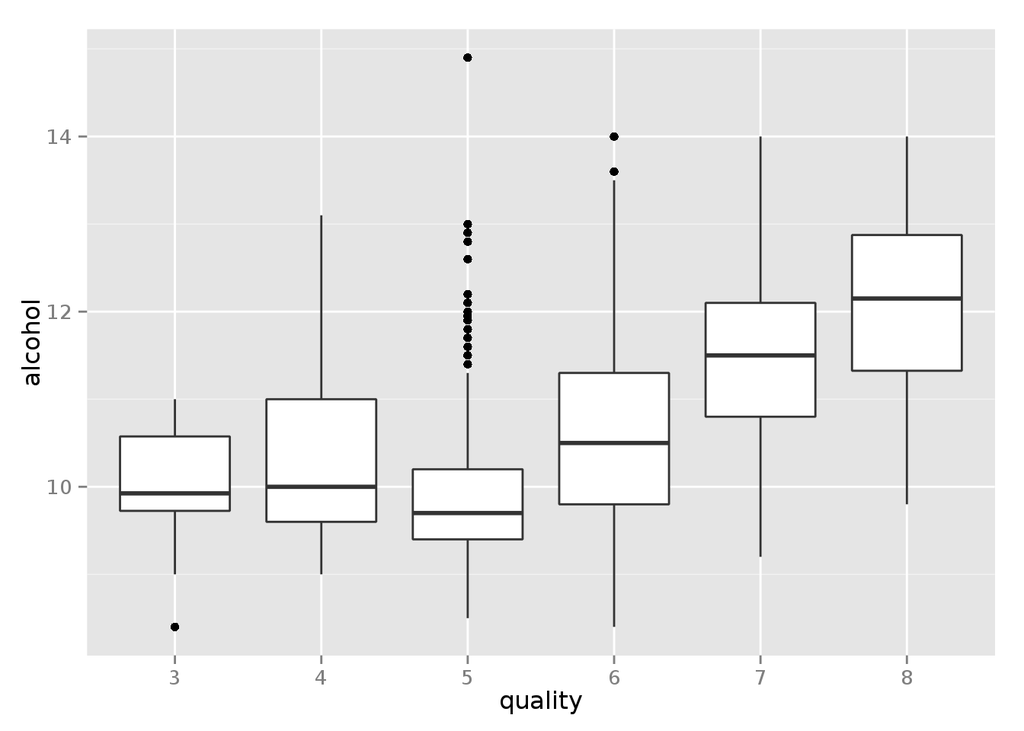

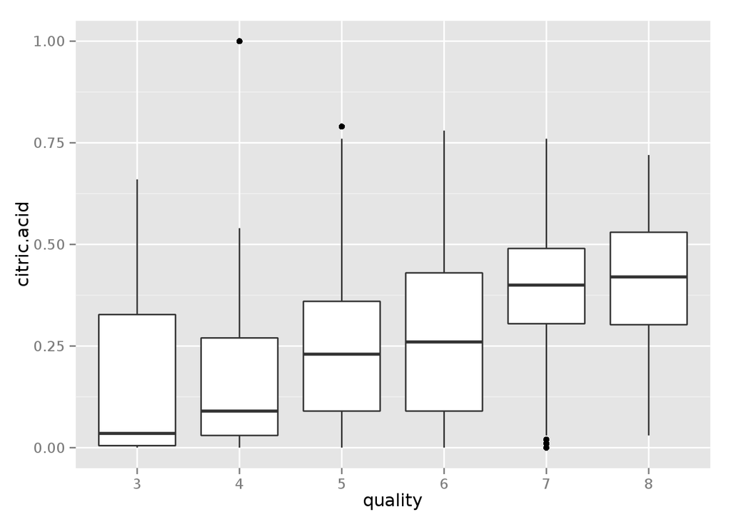

# Bivariate Analysis

### Talk about some of the relationships you observed in this part of the investigation. How did the feature(s) of interest vary with other features in the dataset?

Some interesting relationships were discovered using bivariate analyses. First of all, I previously thought alcohol was not related to quality of wine. However, plotting quality vs alcohol gives a strong suggestion that the latter does affect the quality positively. That is, wines with higher quality tend to have a higher median alcohol. Having mentioned this, it is also worth noting that there were quite a number of observations that had high level of alcohol but not a high quality ranking. Furthermore, residual sugar, which I previously though was very relevant, doesn’t seem to have a strong relationship with quality of wine.

### Did you observe any interesting relationships between the other features (not the main feature(s) of interest)?

What I also noticed was that higher quality wines have lower median values for volatile acidity and pH

### What was the strongest relationship you found?

# Multivariate Plots Section

Let’s now plot some interesting variables in more detail using faceted scatterplots and density plots colored by quality level

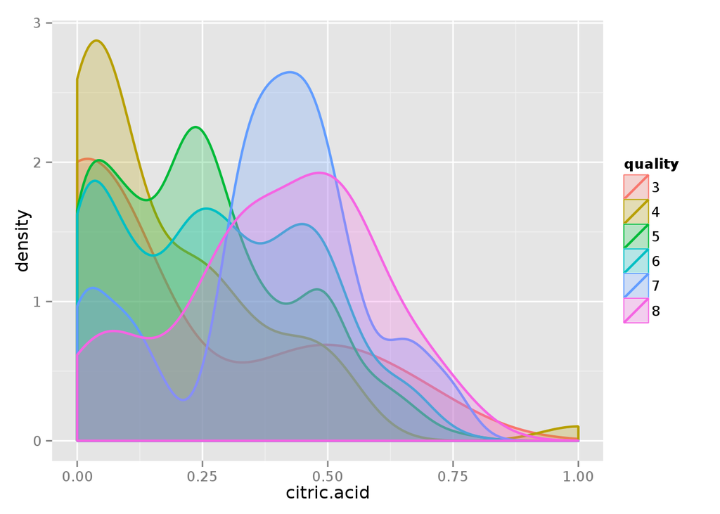

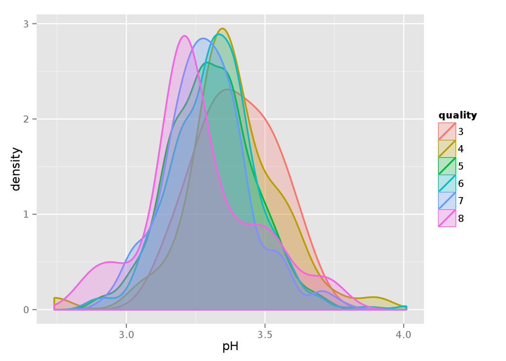

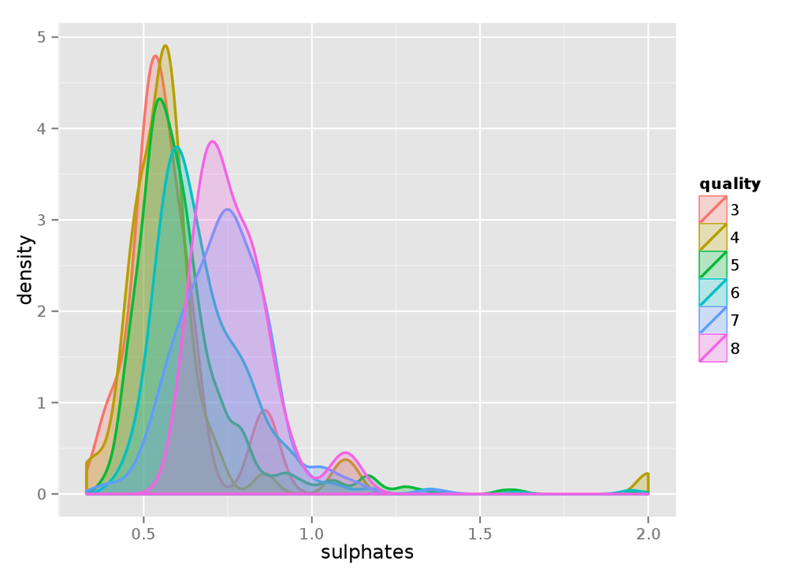

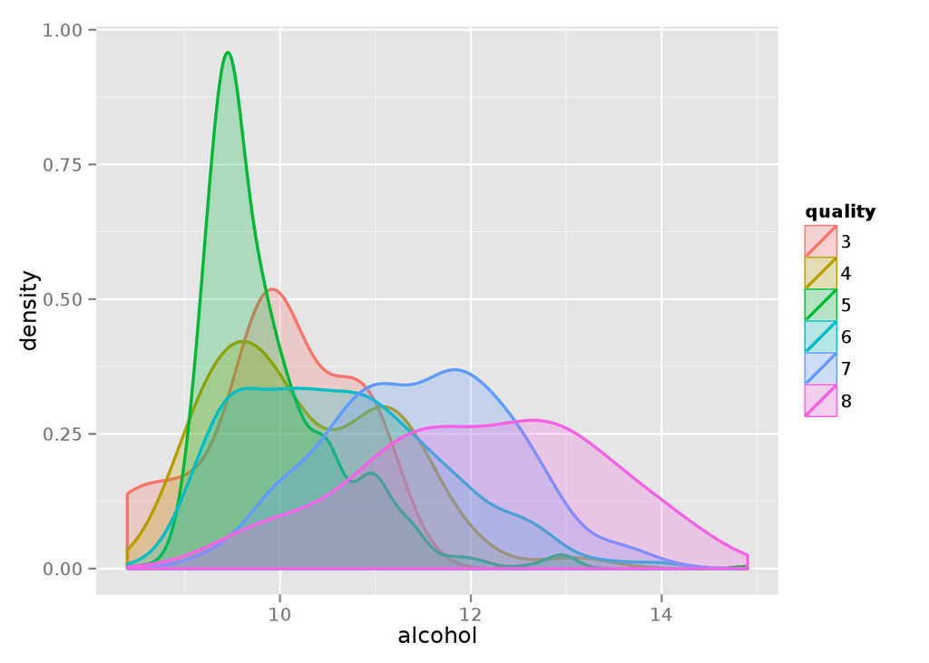

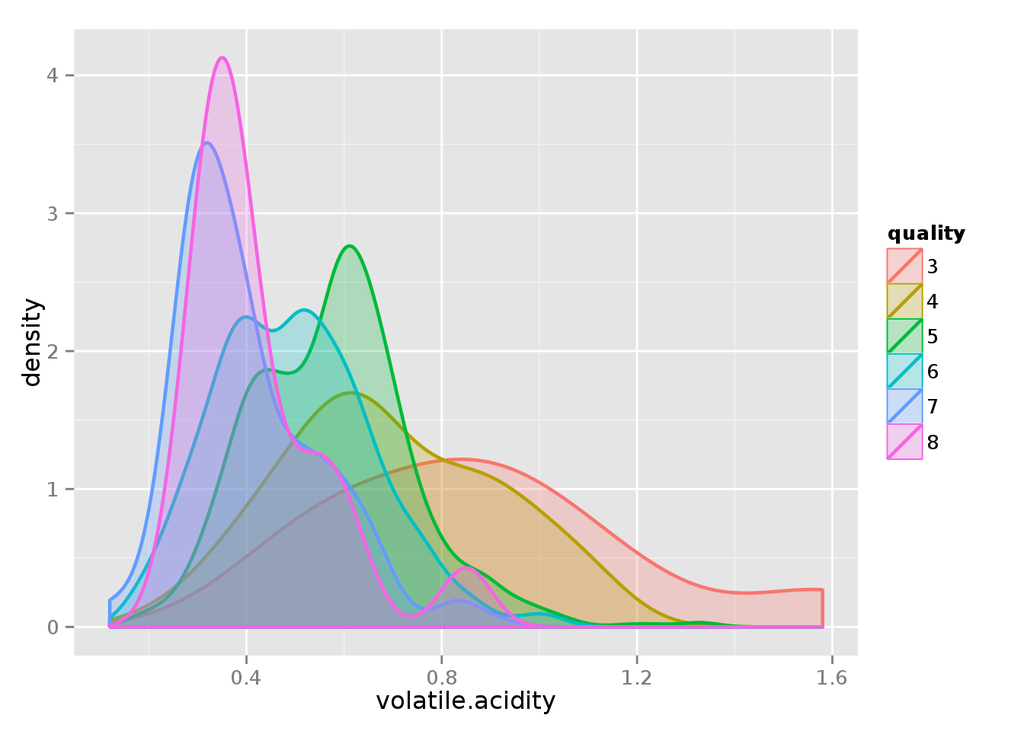

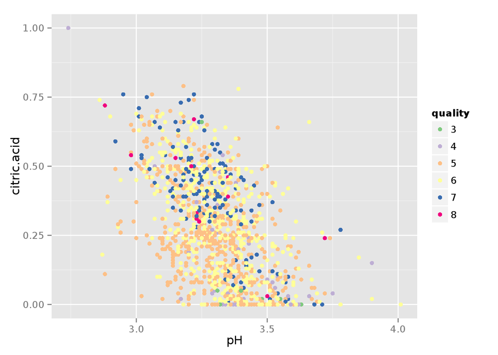

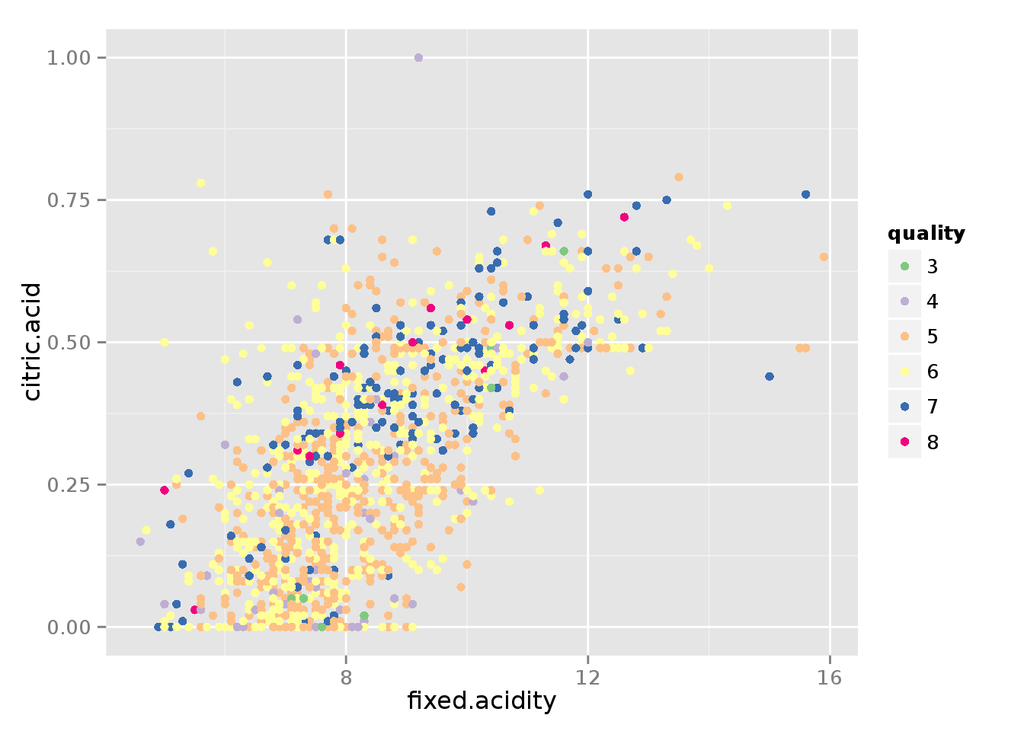

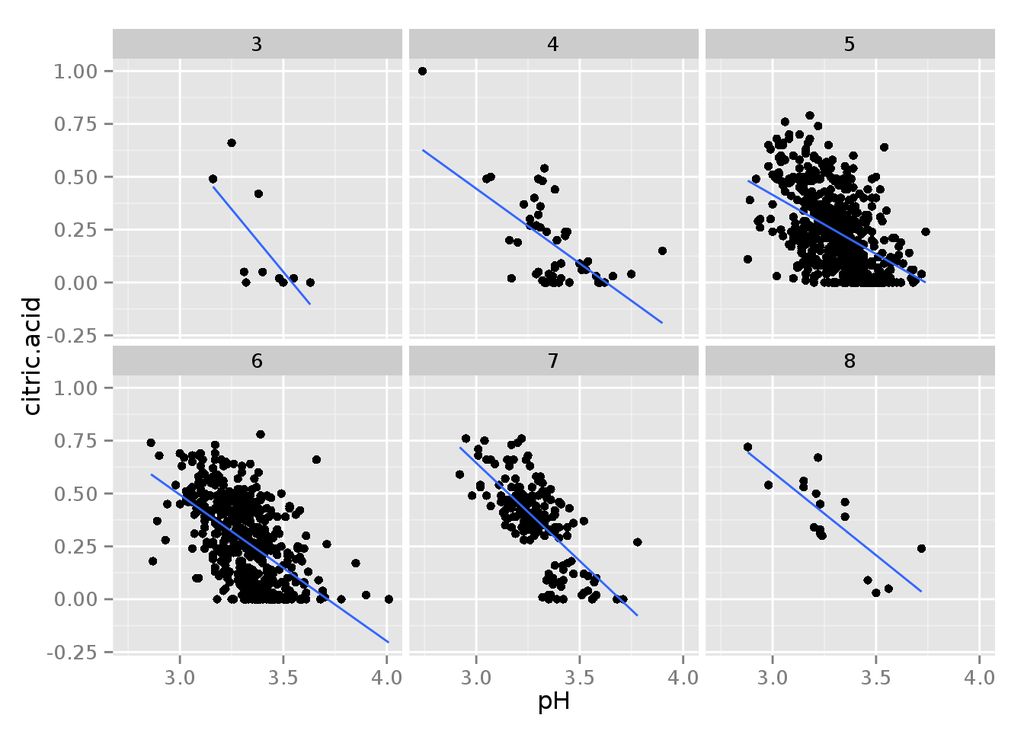

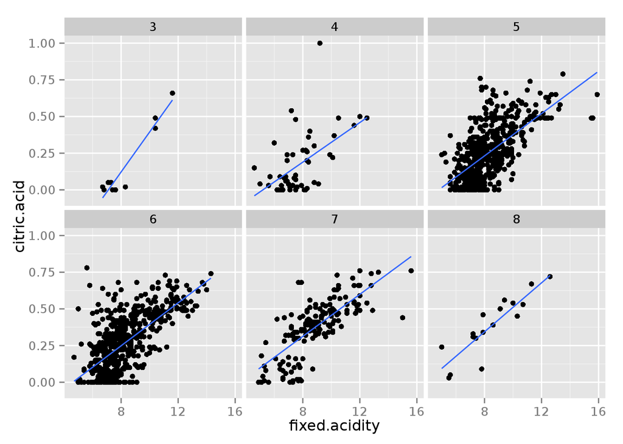

# Multivariate Analysis

### Talk about some of the relationships you observed in this part of the investigation. Were there features that strengthened each other in terms of looking at your feature(s) of interest?

Conducting some multivariate analyses of the main features identified seem to be pointing in the same direction of what was identified previously. That is, the distribution of good wines (7 and 8 rating) with respect to the selected features (see density plots) seems to stand out from lower grade wines. For instance, the distribution of citric acid for good quality wine is more left skewed than the lower grade wine distributions. A similar behaviour is seen with the sulphates density distribution when grouped by quality.

### Were there any interesting or surprising interactions between features?

- Looking at scatterplots faceted by quality shows once again that there are a lot of observations with a quality level of 5 and 6. However, when fitting a linear regression we see that the relationship is very similar in each facet.
- Most of the relationship amongst features seem quite intuitive. For example, the different types of acidity are negatively related to pH, as by definition, pH measures the level of acidity.
- The distribution of citric acid for quality of 5 and 6 seems to be trimodal at very similar levels (close to 0.0, 0.25 and 0.50 g / dm^3)

### OPTIONAL: Did you create any models with your dataset? Discuss the strengths and limitations of your model.

The objective of this exploratory analysis is to understand which features affect the quality of wine. In the course we learnt how to fit a linear regression on a numerical dependent variable. However, this time the dependent variable is categorical in nature, and unfortunately my knowledge of how to conduct this sort of model is extremely limited, hence I didn’t create a model.

# Final Plots and Summary

### Plot One

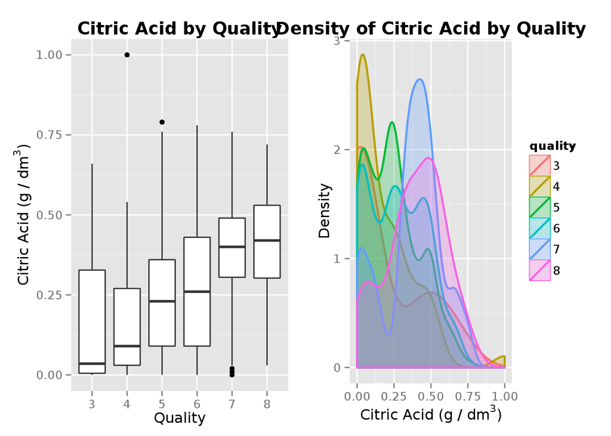

### Description One

Citric acid median is considerably higher for good quality wines (7 and 8). Also, the distribution of citric acid for higher quality wines is left skewed, peaking at around 0.5 g / dm^3, whereas the other distributions peak closer to 0.0 g / dm^3.

### Plot Two

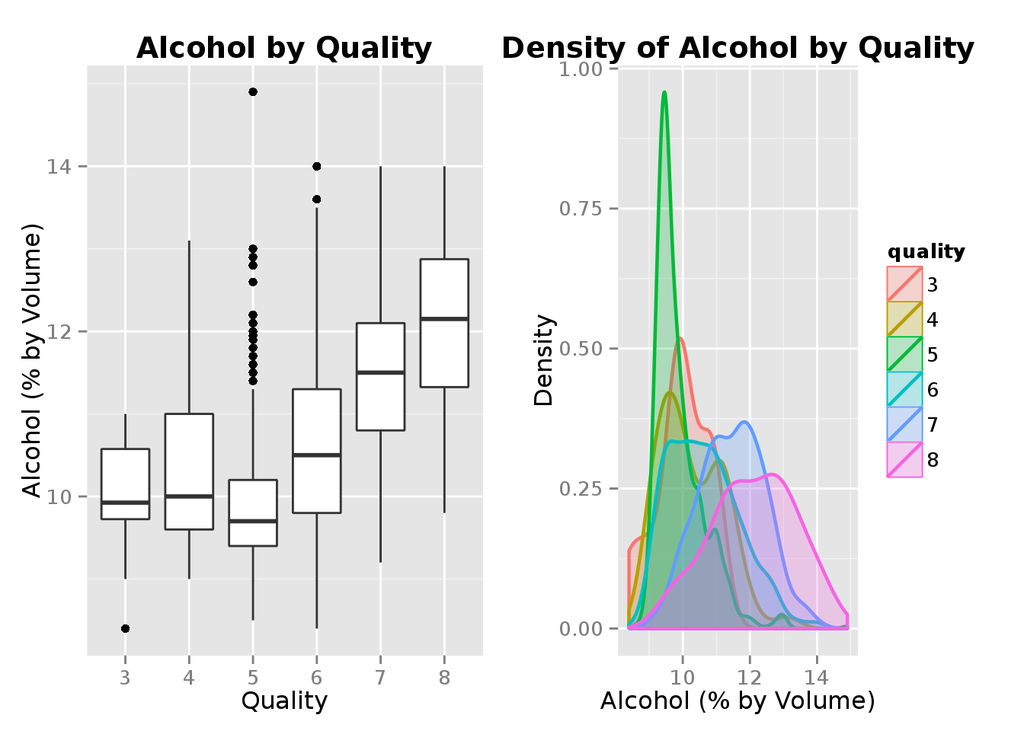